# Trimming audio

```r
# Libraries
library(tidyverse)
library(maps)
library(rgeos)
library(rgdal)
library(table1)
library(seewave)
```

# Problem

- Our cough classifier was trained on very short audio clips. Therefore, it will be most accurate if it gets only short audio clips.
- Also, for reasons of bandwidth, we want to minimize the amount of data we send to the classifier.
- Therefore, we need to be able to identify cough-like sounds, trim them down, and send only the trimmed files to the classifier.

# Read in a minute of audio

Here is a long .wav file. It’s about a minute of miscellaneous sounds (doors, talking, keyboard clicking), including 6 coughs (3 by an adult, 3 by a young child).

```r
library(tuneR)
# Define some functions
html_tag_audio <- function(file,
                           type = "wav"){
  htmltools::tags$audio(controls = NA,
                        htmltools::tags$source(src = file,
                                               type = glue::glue("audio/{type}",
                                                                 type = type)))
}
plot_wave <- function(file){
  wavy <- readWave(filename = file)
  plot(wavy, xlab = 'Seconds', col = adjustcolor('black', alpha.f = 0.5))
}

# Define file with long audio
long_wav <- 'example_audio/long.wav'
```

Here’s what the audio sounds like:

```r
# Make it listenable
html_tag_audio(long_wav)
```

[interactive chart not shown]

Here’s what the audio looks like:

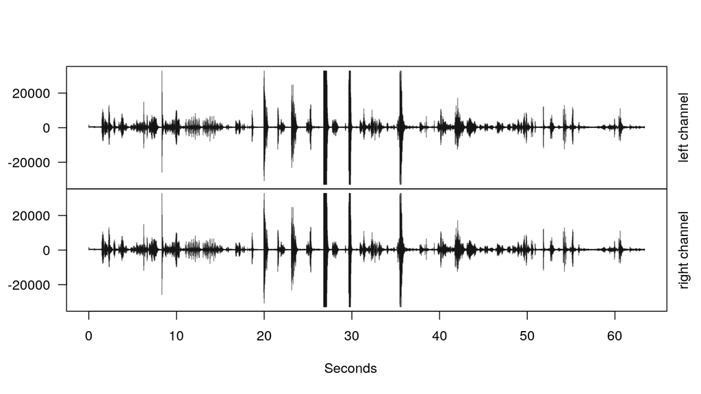

```r
# Show what file looks like
wavy <- readWave(filename = paste0(getwd(), '/', long_wav))
plot(wavy, xlab = 'Seconds', col = adjustcolor('black', alpha.f = 0.5))
```

Let’s process it a bit:

```r
library(tidyverse)
# Extract values
values <- wavy@left
# Extract times (in seconds)
times <- 1:length(values) / wavy@samp.rate
# Combine into dataframe
df <- tibble(time = times,
             value = values)
# It's way too big. We down-sample
df <- df %>%
  mutate(time = round(time, digits = 1)) %>%
  dplyr::distinct(time, .keep_all = T)
```

Let’s overlay the real coughs (blue dots)

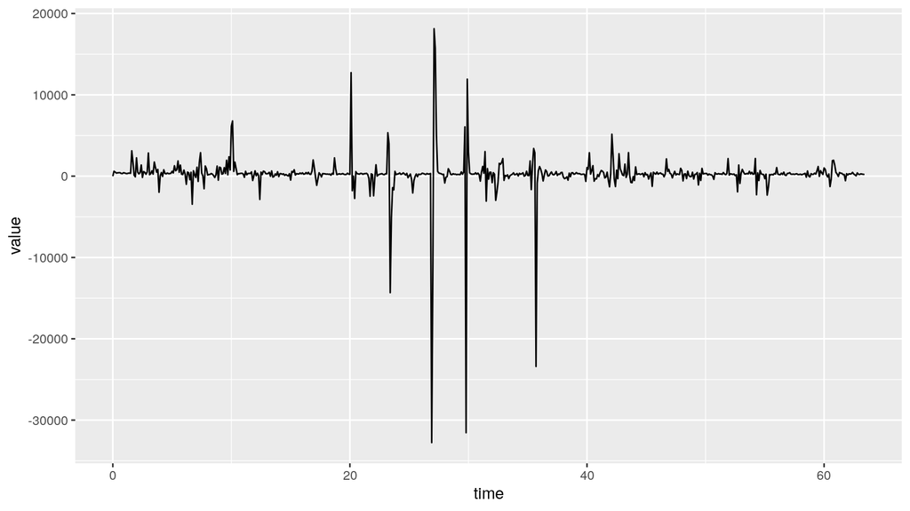

```r
# Plot
ggplot(data = df,
       aes(x = time,
           y = value)) +
  geom_line()
```

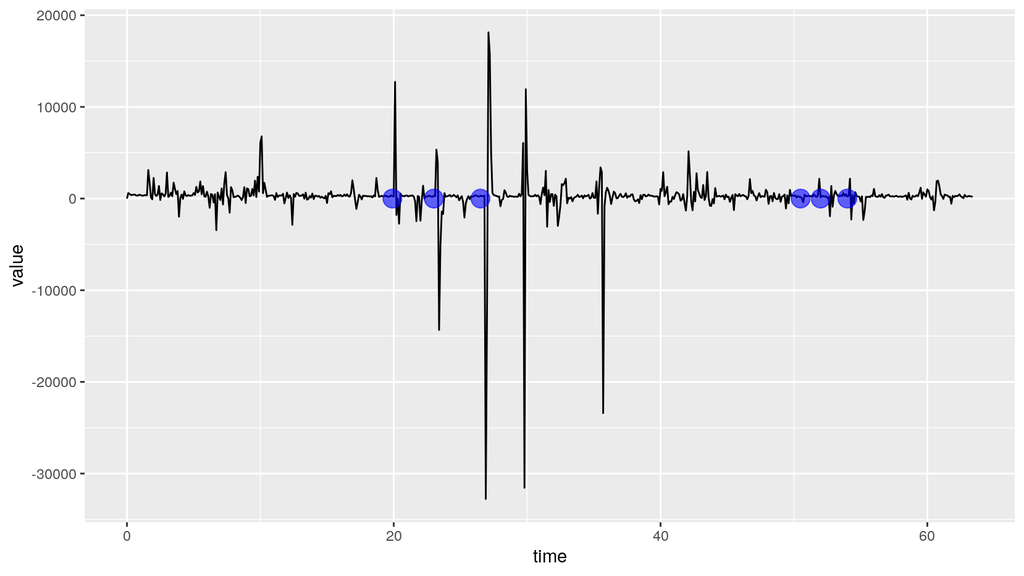

```r
# Show real coughs
real_coughs <- tibble(time = c(19.9, 23, 26.5, 50.5, 52, 54),
                      value = 0)

ggplot(data = df,
       aes(x = time,
           y = value)) +
  geom_line() +
  geom_point(data = real_coughs,
             color = 'blue',
             size = 5,
             alpha = 0.6)
```

# Method 1

Smooth the data and find peaks by copmparing a local maximum filter to the smooth

```r
argmax <- function(x, y, w=1, ...) {
  require(zoo)
  n <- length(y)
  y.smooth <- loess(y ~ x, ...)$fitted
  y.max <- rollapply(zoo(y.smooth), 2*w+1, max, align="center")
  delta <- y.max - y.smooth[-c(1:w, n+1-1:w)]
  i.max <- which(delta <= 0) + w
  list(x=x[i.max], i=i.max, y.hat=y.smooth)
}

peaks <- argmax(x = df$time,
                y = df$value,
                w = 5,
                span = 0.05)
peaks_df <- tibble(time = peaks$x,
                   value = df$value[peaks$i])
```

Show detected points (red) and real coughs (blue)

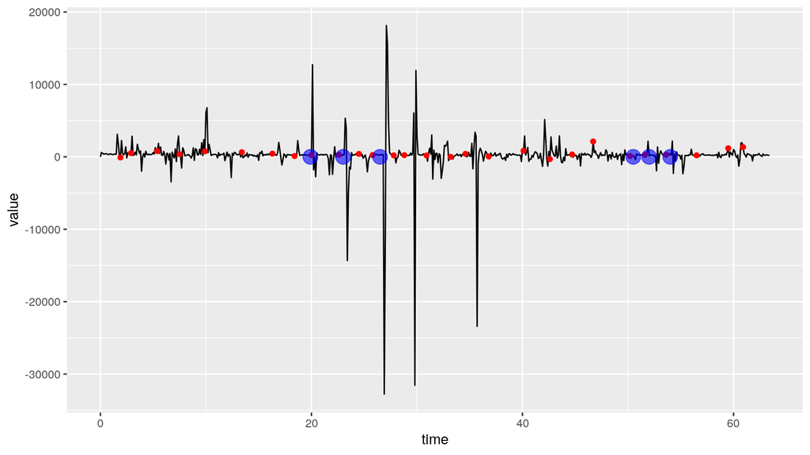

```r
# Plot
ggplot(data = df,
       aes(x = time,
           y = value)) +
  geom_line() +
  geom_point(data = peaks_df,
             color = 'red') +
  geom_point(data = real_coughs,
             color = 'blue',
             size = 5,
             alpha = 0.6)
```

Let’s define the audio to cut and cut it

```r
# Return the 0.5 seconds nearest to each peak
start_stops <- list()
for(i in 1:nrow(peaks_df)){
  start_stops[[i]] <- peaks_df[i,] %>%
    mutate(start = time - 0.25,
           stop = time + 0.25)
}
dir.create('send_to_api')
send_to_api <- bind_rows(start_stops)
for(i in 1:nrow(send_to_api)){
  tr = readWave(long_wav, from = send_to_api$start[i], to = send_to_api$stop[i],
                units = "seconds")
  savewav(wave = tr,
           filename = paste0('send_to_api/', i, '.wav'))
}
```

Probably over-sensitive (got 2 dozen files). Could be optimized / improved. Here are what they sound like

```r
html_tag_audio('send_to_api/6.wav')
```

[interactive chart not shown]

```r
html_tag_audio('send_to_api/7.wav')
```

[interactive chart not shown]

```r
html_tag_audio('send_to_api/8.wav')
```

[interactive chart not shown]

```r
html_tag_audio('send_to_api/9.wav')
```

[interactive chart not shown]

```r
html_tag_audio('send_to_api/10.wav')
```

[interactive chart not shown]

```r
html_tag_audio('send_to_api/11.wav')
```

[interactive chart not shown]

```r
html_tag_audio('send_to_api/12.wav')
```

[interactive chart not shown]

```r
html_tag_audio('send_to_api/13.wav')
```

[interactive chart not shown]

```r
html_tag_audio('send_to_api/14.wav')
```

[interactive chart not shown]

```r
html_tag_audio('send_to_api/15.wav')
```

[interactive chart not shown]

# Method 2

Here’s another method using pre-built algos for signal detection

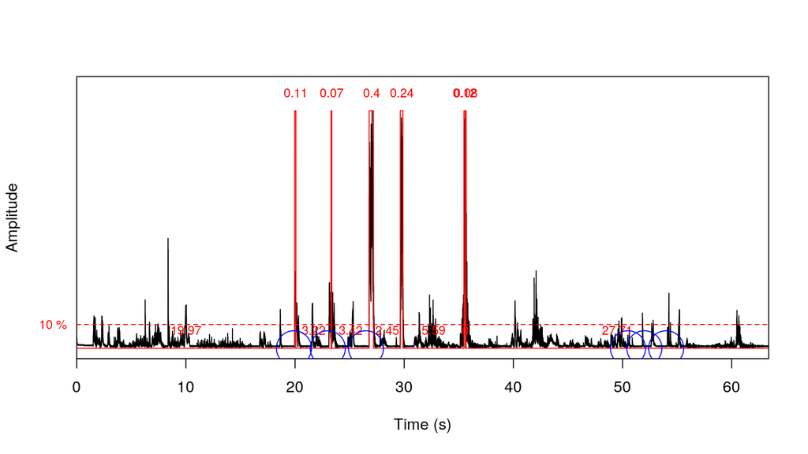

```r
t <- timer(wavy, threshold=10, msmooth=c(100,0), dmin=0.05)
points(real_coughs$time,
       real_coughs$value,
       col = 'blue',
       cex = 5)
```

```r
mid_point <- (t$s.start + t$s.end) /2
send_to_api2 <- tibble(start = mid_point - 0.25,
                       stop = mid_point + 0.25)
dir.create('send_to_api2')
for(i in 1:nrow(send_to_api2)){
  tr = readWave(long_wav, from = send_to_api2$start[i], to = send_to_api2$stop[i],
                units = "seconds")
  savewav(wave = tr,
           filename = paste0('send_to_api2/', i, '.wav'))
}
```

Let’s listen:

```r
html_tag_audio('send_to_api2/1.wav')
```

[interactive chart not shown]

```r
html_tag_audio('send_to_api2/2.wav')
```

[interactive chart not shown]

```r
html_tag_audio('send_to_api2/3.wav')
```

[interactive chart not shown]

```r
html_tag_audio('send_to_api2/4.wav')
```

[interactive chart not shown]

```r
html_tag_audio('send_to_api2/5.wav')
```

[interactive chart not shown]

```r
html_tag_audio('send_to_api2/6.wav')
```

[interactive chart not shown]